# Session2: Hypothesis Testing and ANOVA

MRC Clinical Sciences Centre (http://mrccsc.github.io/)  
12/July/2016

### Hypothesis testing and ANOVA

- SD (standard deviation) and SE (standard error; standard error of sample mean)
- Confidence Interval (CI)
- Hypothesis testing

  – parametric test:e.g. t-test

  – non-parametric test: e.g. Wilcoxon test; chi-square test and Fisher's exact test
- Analysis of Variance (ANOVA)

### Statistical tests

On top of descriptive statistics, R has several statistical tests covering a range of problems and data types.

Some common tests include:

- var.test() - Comparing 2 variances (Fisher's F test)
- t.test() - Comparing 2 sample means with normal errors (Student's t-test)
- binom.test() - Performs an exact test of a simple null hypothesis about the probability of success in a Bernoulli experiment.
- wilcox.test() - Comparing 2 means with non-normal errors (Wilcoxon's rank test)
- fisher.test() - Testing for independence of 2 variables in a contingency table (Fisher's exact test)

### Hypothesis test in propotion

[example: EU referendum reuslt 2016]

### Hypothesis test in propotion

[example: EU referendum reuslt 2016] [data/EU-referendum-result-data.csv] Is the leave vote more than the 50%?

```r
vote.leave=17410742
vote.remain=16141241
total.vote=vote.leave+vote.remain
```

### Hypothesis test in propotion

\[ H_0:\text{ Leave vote is more than 50%} \\ H_a:\text{ Leave vote is no more than 50%} \]

```r
binom.test(vote.leave, total.vote, p=0.5, alternative = "less")
```

```
    Exact binomial test

data:  vote.leave and total.vote
number of successes = 17411000, number of trials = 33552000,
p-value = 1
alternative hypothesis: true probability of success is less than 0.5
95 percent confidence interval:
 0.0000000 0.5190603
sample estimates:
probability of success
             0.5189184
```

### Hypothesis test in mean

t-test

### t-test example - Load data (1/2)

We use “PlantGrowth” as example

```r
PlantGrowth
```

```
   weight group
1    4.17  ctrl
2    5.58  ctrl
3    5.18  ctrl
4    6.11  ctrl
5    4.50  ctrl
6    4.61  ctrl
7    5.17  ctrl
8    4.53  ctrl
9    5.33  ctrl
10   5.14  ctrl
11   4.81  trt1
12   4.17  trt1
13   4.41  trt1
14   3.59  trt1
```

[output cut: 16 more lines]

data visualisation

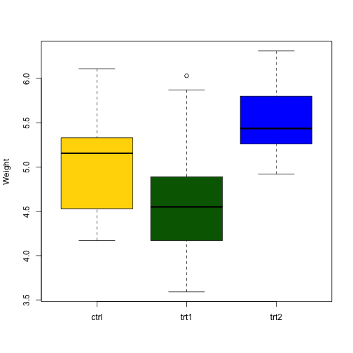

### t-test example - Load data (2/2)

Convert the input data into the proper format

```r
#install.packages("tidyr")
library("tidyr")
PlantGrowth_wide<-spread(PlantGrowth, group, weight)
```

[output not shown]